# Embedding and Bias Analysis

related to https://stdm.github.io/downloads/papers/ANNPR_2020.pdf

### Vorhersage der Prediction Rate

Spannend wäre, wenn die Abweichung der Prediction Rate für verschiedene Klassen anhand von Datesets mit nur Labels der Klassen vorausgesagt werden könnte (also ohne Labels für gleiche Personen). Hier habe ich folgende Erkenntnisse

- Verteilungen von Distanzen funktionieren eher nicht so gut. Grund könnte sein, dass distancen 1-dim Masse sind und eigentlich nicht gut abbilden, wieviel Volumen im Hyperraum abgebiltet ist
- Volumen im Hyperraum werden wohl besser durch PCA und Varianz abgebiltet. Darum führe ich unten ein simples Mass für den 'spread' der Varianz über die Dimensionen ein. Das Mass scheint vielversprechend für 128 / 256. Funktioniert aber für ft nicht gut (da hat aber auch die Varianz einen Knick -> Artefakt?)
- Interessanterweise gibt auch die mittlerer Anzahl von nn-Nachbarn derselben Klasse gut Auskunft über die Recognition rate.

### Bemerkungen

- Die Embeddings-Vektoren sind normalisiert (daher: sie leben auf einer Hyper-Kugel)
- Feature-Vektoren sind nicht normalisiert

### Literatur, Links

- https://towardsdatascience.com/introduction-to-best-parallel-plot-python-library-hiplot-8387f5786d97
- https://machinelearningmastery.com/how-to-perform-face-recognition-with-vggface2-convolutional-neural-network-in-keras/

### Import and Helpers

```python
import pandas as pd
import numpy as np
import matplotlib.pyplot as plt

import hiplot as hip
from sklearn.decomposition import PCA
```

```python
def distances(X1, X2):
    out = [np.sqrt(np.sum((X2-x)**2,1)) for x in X1]
    return np.array(out)

def cos_similarity(X1, X2):  # all distances between embedding vectors X1 and X2
    out = [np.sum(X2*x,1) for x in X1]
    return np.array(out)

def cumdist(v):  # x, y for cumulative density plot
    x = np.sort(v.flatten())
    y = np.arange(len(x))/len(x)
    return x, y
```

```python
class H5Reader:
    pattern = r'C:\Daten\FaceRecognitionBias\senet50\embeddings\senet50_{net}_pytorch_{race}_normed_BGR.h5'
    race_list = ['Caucasian','Indian','Asian','African']
    net_list = ['128','256','ft']
    hdf_key = '/embeddings'

    def __init__(self, net):
        self.net = net

    def race(self, prefix):
        return list(filter(lambda s: s.lower().startswith(prefix.lower()),self.race_list))[0]

    def path(self, race):
        race = list(filter(lambda s: s.lower().startswith(race.lower()),self.race_list))[0]
        return self.pattern.format(net = self.net, race = race)

    def read(self, race_prefix, race_index = False):
        race = self.race(race_prefix)
        path = self.pattern.format(net = self.net, race = race)
        df = pd.read_hdf(path, self.hdf_key)
        if race_index:
            df['race_index'] = self.race_list.index(race)
        return df

    def read_all(self, N=None, select = 'head'):
        out = []
        for race in self.race_list:
            df = self.read(race, race_index=True)
            if N is None:
                out.append(df)
            elif select == 'head':
                out.append(df.head(N))
            else:
                out.append(df.tail(N))

        return pd.concat(out,0).set_index('race_index').reset_index()

    def keys(self, race_prefix):
        race = self.race(race_prefix)
        path = self.pattern.format(net = self.net, race = race)
        with pd.HDFStore(path) as hdf:
            out = hdf.keys()
        return out

r128 = H5Reader('128')
r128.keys('c')
```

```
['/embeddings', '/images', '/no_face_found_df']
```

# 1. Distance Measures

Note: Graphs below show cumulative distributions!

### Next Steps

- [ ] Alles mit Euklidischer Distanz rechnen
- [x] Nur die nächsten Nachbarn anschauen
- [ ] Make nearest neighbor plot over all three nets
- [ ] Further investigate confusion matrices

## 1.1 Cosine similarities

- Cosine similarity fits the fact that embedding vectors are normalized. I.e. they lie on a hyper-sphere and therefore angles between points makes sense.
- Caucasian und African seem to be different.
- senet50_ft does not fill the full embedding space
- Recognition rates of https://stdm.github.io/downloads/papers/ANNPR_2020.pdf are not directly visible

```python
def cos_cdf(reader, race1, race2, N = 1000):
    X1 = reader.read(race1).values[:N]
    X2 = reader.read(race2).values[(-N):]
    d = cos_similarity(X1, X2)
    return cumdist(d)
```

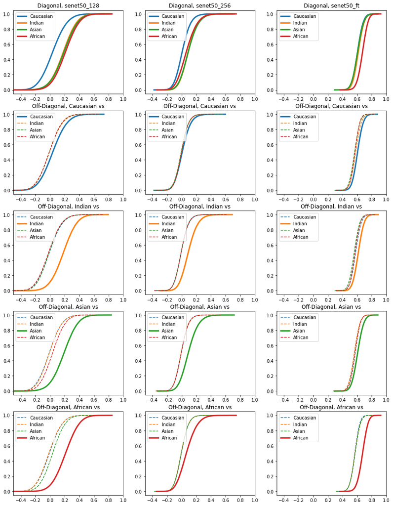

```python
fig, axs = plt.subplots(5, 3, figsize=[15,20],)
#fig.suptitle('Cosine Similarities')
for inet, net in enumerate(['128','256','ft']):
    reader = H5Reader(net)
    for irace, race1 in enumerate(H5Reader.race_list):
        for race2 in H5Reader.race_list:
            x, y = cos_cdf(reader,race1, race2, N=1000)
            if race1 == race2:
                axs[irace+1, inet].plot(x, y, label=race2, lw=3)
                axs[0, inet].plot(x, y, label=race2, lw=3)
            else:
                axs[irace+1, inet].plot(x, y, label=race2, ls = '--')
        axs[irace+1,inet].set_title('Off-Diagonal, '+race1+' vs')
        axs[irace+1,inet].legend(loc='upper left')
        axs[irace+1,inet].set_xlim([-0.5,1])
    axs[0,inet].set_title('Diagonal, senet50_'+net)
    axs[0,inet].legend(loc='upper left')
    axs[0,inet].set_xlim([-0.5,1])

plt.savefig('cosine_similarities.png',papertype='A4',dpi=200)
plt.show()
```

### Nearest Neighbor analysis & Confusion matrix

Maybe only the nearest neighbors count -> Investigate the distribution of nearest neighbor cosine similarities.

- NN distributions show similar hirarchy as full pairwise distributions
- Interestingly: Low average number of same-class neighbors correlates with high recognition rate (see ttps://stdm.github.io/downloads/papers/ANNPR_2020.pdf)

```python
N = 4000
rd = H5Reader('128')
df1 = rd.read_all(N=N)
df2 = rd.read_all(N=N, select='tail')
d = cos_similarity(df1.iloc[:,1:].values, df2.iloc[:,1:].values)
```

```python
resdf = df1.iloc[:,[0]]
resdf['nn_race_index'] = df2.race_index.reindex(np.argmax(d,1)).values
resdf['cos_sim'] = np.max(d,1)
resdf
```

|  | race_index | nn_race_index | cos_sim |
| --- | --- | --- | --- |
| 0 | 0 | 0 | 0.563088 |
| 1 | 0 | 0 | 0.479870 |
| 2 | 0 | 0 | 0.593628 |
| 3 | 0 | 0 | 0.604804 |
| 4 | 0 | 0 | 0.567806 |
| ... | ... | ... | ... |
| 15995 | 3 | 3 | 0.561688 |
| 15996 | 3 | 3 | 0.628396 |
| 15997 | 3 | 3 | 0.659514 |
| 15998 | 3 | 3 | 0.641369 |
| 15999 | 3 | 3 | 0.667825 |

16000 rows × 3 columns

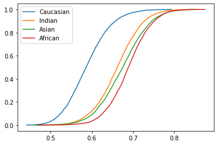

```python
for irace, race in enumerate(H5Reader.race_list):
    x, y = cumdist(resdf.query('race_index==@irace').cos_sim.values)
    plt.plot(x, y, label = race)
plt.legend()
plt.show()
```

```python
#confusion matrix
confmat = np.zeros([4,4])
for i in range(4):
    for j in range(4):
        confmat[i,j] = np.mean(resdf.query('race_index==@i').nn_race_index == j)
confmat
```

```
array([[0.81775, 0.0945 , 0.053  , 0.03475],
       [0.04825, 0.91725, 0.015  , 0.0195 ],
       [0.0205 , 0.02275, 0.948  , 0.00875],
       [0.0045 , 0.0195 , 0.007  , 0.969  ]])
```

# 2. PCA and variance

### Next Steps

- [x] Einfluss von Solvern, Accuracy -> Bei solver 'full' gibt es keine Einstellungen
- [ ] Normalisierung & Intercept für PCA untersuchen
- [ ] Knick bei senett50_ft untersuchen
- [ ] Alternative Masse im Zusammenhang mit Varianz & PCA untersuchen. Klären, was die geom. Interpretation ist.
- [ ] Verschiedene Arten von Varianze-Rechnung einführen (ev. PCA für gasammte Daten und dann Projektion). Rumspielen. Geom sinnvoll interpretieren.

## 2.1. Variance analysis

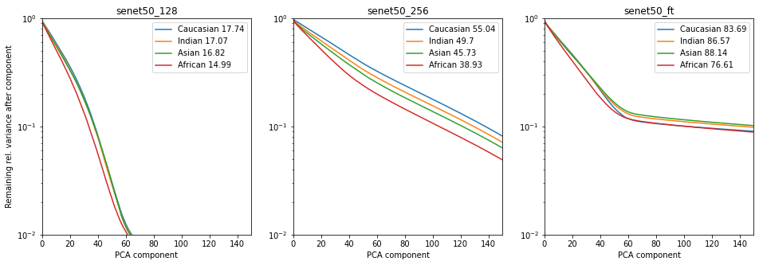

```python
pca = PCA(svd_solver='full')
N=9500

hmat = np.zeros([3,4])
fig, axs = plt.subplots(1, 3, figsize=(16,5))
for inet,net in enumerate(H5Reader.net_list):
    rd = H5Reader(net)
    for irace,race in enumerate(H5Reader.race_list):
        X = rd.read(race).head(N).values
        pca.fit(X)
        var = pca.explained_variance_ratio_
        h = np.dot(var,np.arange(len(var)))
        hmat[inet,irace]=h
        axs[inet].semilogy(1 - np.cumsum(var),label=race+' '+str(np.round(h,2)))
    axs[inet].legend()
    axs[inet].set_title('senet50_'+net)
    axs[inet].set_ylim([0.01,1])
    axs[inet].set_xlim([0,150])
    axs[inet].set_xlabel('PCA component')
    if inet == 0:
        axs[inet].set_ylabel('Remaining rel. variance after component')

plt.show()
```

### Variance spread and recognition rate

PCA calculates normalized variance $p_i$ such that $\sum p_i = 1$. Here I define a variance spread as

$$ h = \sum_i i * p_i $$

- Bigger h means that variance spreads over more components, i.e. more dimensions.
- Below: h is calculated with a seperate pca for each class (this could also be changed).
- Fit is done with a fit-paremeter per model

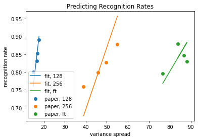

```python
# recognition rate
recrate=[[0.8906,0.8531,0.8310,0.7998],
        [0.8787,0.8265,0.7981,0.7597],
        [0.8799,0.8472,0.8305,0.7959]]

recrate_fit = hmat*np.mean(recrate/hmat,1,keepdims=1)

for inet, net in enumerate(H5Reader.net_list):
    plt.scatter(hmat[inet],recrate[inet],label='paper, ' + net)
    plt.plot(hmat[inet],recrate_fit[inet],label='fit, '+net)
plt.legend()
plt.xlabel('variance spread')
plt.ylabel('recognition rate')
plt.title('Predicting Recognition Rates')
plt.show()
```

### Distribution functions of PCA prejections

Here PCA was done on all classes

```python
N = 9500
pca_dict = {}
for net in H5Reader.net_list:
    df = H5Reader(net).read_all()
    X = df.values[:,1:]
    pca = PCA(n_components=10)
    Xp = pca.fit_transform(X)
    pca_dict[net] = pd.concat([df.drop(columns=df.columns[1:]),pd.DataFrame(data=Xp)],1)
```

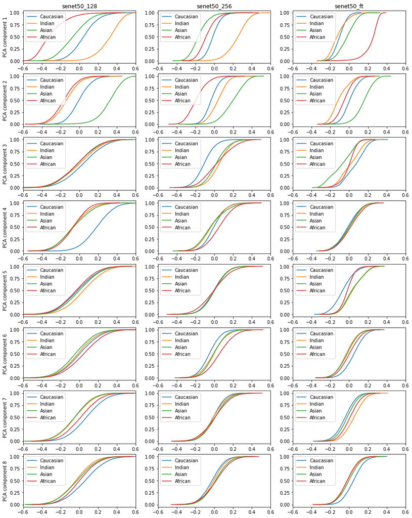

```python
Npca = 8
fig, axs = plt.subplots(Npca, 3, figsize=[15,20],)
#fig.suptitle('Cosine Similarities')
for inet, net in enumerate(H5Reader.net_list):
    for ipca in range(Npca):
        for irace, race in enumerate(H5Reader.race_list):
            x, y = cumdist(pca_dict[net].query('race_index==@irace')[ipca].values)
            axs[ipca, inet].plot(x,y,label=race)
        if ipca == 0:
            axs[ipca, inet].set_title('senet50_'+net)
        axs[ipca, inet].legend(loc='upper left')
        axs[ipca,inet].set_xlim([-0.6,0.6])
        if inet == 0:
            axs[ipca,inet].set_ylabel('PCA component '+str(ipca + 1))

plt.savefig('pca.png',papertype='A4',dpi=200)
plt.show()
```